# Markov_Matrices

We know from *theorem 7.12* that $X_s$ has positive entries which have the same sum as the entries of $X_0$. Therefore, \begin{align*} \text{Sum of entries of }X_s&=\text{Sum of entries of }X_0\\ 0.25t+0.25t+ t&=100+200+400 \end{align*} Solving for $t$, we get $t=\dfrac{1400}{3}$. Therefore the population in the long run is given by $$\frac{1400}{3}\begin{bmatrix}0.25 \\ 0.25 \\ 1\end{bmatrix}= \begin{bmatrix}\frac{350}{3}\\ \frac{350}{3}\\ \frac{1400}{3}\end{bmatrix}.$$ Since we are speaking about populations, we would need to round these numbers to provide a logical answer. The steady state vector $X_s$ is given by $$X_s= \begin{bmatrix}117\\ 117\\ 467\end{bmatrix}.$$

**Example 7.30** A man eats one of three soups—beef, chicken, and vegetable—each day. He never eats the same soup two days in a row. If he eats beef soup on a certain day, he is equally likely to eat each of the others the next day; if he does not eat beef soup, he is twice as likely to eat it the next day as the alternative.

- (a) If he has beef soup one day, what is the probability that he has it again two days later?
- (b) What are the long-run probabilities that he eats each of the three soups?

The states here are $B$, $C$, and $V$, the three soups. The transition matrix $A$ is given in the table. (Recall that, for each state, the corresponding column lists the probabilities for the next state.)

|  | B | C | V |
| --- | --- | --- | --- |
| B | 0 | 2/3 | 2/3 |
| C | 1/2 | 0 | 1/3 |
| V | 1/2 | 1/3 | 0 |

If he has beef soup initially, then the initial state vector is \begin{align*} X_0 = \left[\begin{array}{l} 1 \\ 0 \\ 0 \end{array}\right] \begin{array}{c}B \\ C \\ V \end{array} \end{align*} Then two days later the state vector is $X_2$ . If $A$ is the transition matrix, then \begin{align*} X_1=AX_0= \left[\begin{array}{ccc} 0 & \frac{2}{3} & \frac{2}{3}\\ \frac{1}{2} & 0 & \frac{1}{3}\\ \frac{1}{2} & \frac{1}{3} & 0 \end{array}\right] \left[\begin{array}{c} 1\\ 0\\ 0 \end{array}\right]=\left[\begin{array}{c} 0\\ \frac{1}{2}\\ \frac{1}{2} \end{array}\right],\\ X_2=AX_1=AAX_0=A^2X_0= \left[\begin{array}{ccc} 0 & \frac{2}{3} & \frac{2}{3}\\ \frac{1}{2} & 0 & \frac{1}{3}\\ \frac{1}{2} & \frac{1}{3} & 0 \end{array}\right] \left[\begin{array}{c} 0\\ \frac{1}{2}\\ \frac{1}{2} \end{array}\right]=\left[\begin{array}{c} \frac{2}{3}\\ \frac{1}{6}\\ \frac{1}{6} \end{array}\right] \begin{array}{c}B \\ C \\ V \end{array} \end{align*} so he eats beef soup two days later with probability $\dfrac{2}{3}$.

Moreover, this also shows that he eats chicken and vegetable soup each with probability $\dfrac{1}{6}$.

To find the long-run probabilities, we must find the steady-state vector $X_s$.

\begin{align*} X_s = AX_s \Rightarrow (I-A)X_s=0 \quad \Rightarrow \quad & \left(\begin{bmatrix}1 & 0 & 0\\ 0 & 1 & 0\\ 0 & 0 & 1\end{bmatrix} - \left[\begin{array}{ccc} 0 & \frac{2}{3} & \frac{2}{3}\\ \frac{1}{2} & 0 & \frac{1}{3}\\ \frac{1}{2} & \frac{1}{3} & 0 \end{array}\right] \right)X_s= \begin{bmatrix}0\\0\\0\end{bmatrix}, \\ \quad \Rightarrow \quad & \left[\begin{array}{ccc|c} 1 & -\frac{2}{3} & -\frac{2}{3} & 0\\ -\frac{1}{2} & 1 & -\frac{1}{3} & 0\\ -\frac{1}{2} & -\frac{1}{3} & 1 & 0 \end{array}\right]X_s= \begin{bmatrix}0\\0\\0\end{bmatrix}. \end{align*}

The general solution: \begin{align*} X_s=t\left[\begin{array}{c} \frac{4}{3}\\ 1\\ 1 \end{array}\right]. \end{align*} We know from *theorem 7.12* that $X_s$ has positive entries which have the same sum as the entries of $X_0$. Therefore, \begin{align*} \frac{4\,t}{3}+ t+ t=1+0+0. \quad \Rightarrow \quad \frac{10\,t}{3}=1 \quad \Rightarrow \quad t=\frac{3}{10}=0.3 \end{align*} Therefore, the steady state vector $X_s$ is given by \begin{align*} X_s= (0.3)\left[\begin{array}{c} \frac{4}{3}\\ 1\\ 1 \end{array}\right]= \left[\begin{array}{c} 0.4\\ 0.3\\ 0.3 \end{array}\right] \begin{array}{c} B \\ C \\ V \end{array}. \end{align*} Hence, in the long run, he eats beef soup 40\% of the time and eats chicken soup and vegetable soup each 30\% of the time.

```python
A=Matrix([[0,0.666667,0.666667],[0.500000,0,0.333333],[0.500000,0.333333,0]])
print('A='),
A
```

```
A=
```

$\displaystyle \left[\begin{matrix}0 & 0.666667 & 0.666667\\0.5 & 0 & 0.333333\\0.5 & 0.333333 & 0\end{matrix}\right]$

```python
X0=Matrix([[1],[0],[0]])
X0
```

$\displaystyle \left[\begin{matrix}1\\0\\0\end{matrix}\right]$

We have $$ X_{n+1} = PX_n,\quad n=1,2,3,\ldots. $$

We can now successively compute $X_1$, $X_2$, $\ldots$

```python
print('X%s' % 1)
A*X0
```

```
X1
```

$\displaystyle \left[\begin{matrix}0\\0.5\\0.5\end{matrix}\right]$

```python
print('X%s' % 2)
A**2*X0
```

```
X2
```

$\displaystyle \left[\begin{matrix}0.666667\\0.1666665\\0.1666665\end{matrix}\right]$

```python
N=150
Xn=zeros(3,N+1)
for n in range(0,N):
    Xn[:,n]=A**n*X0
```

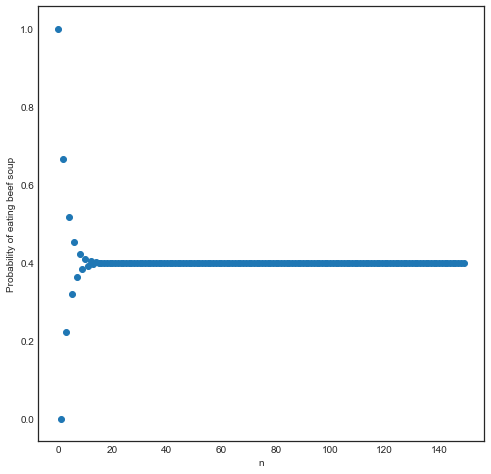

```python
import matplotlib.pyplot as plt
# Figure size is Figure size 800x800 with 1 Axes
plt.figure(figsize = (8, 8))
plt.scatter(list(range(0, N)),Xn[0,range(0,N)])
plt.xlabel('n')
plt.ylabel('Probability of eating beef soup')
plt.show()
```

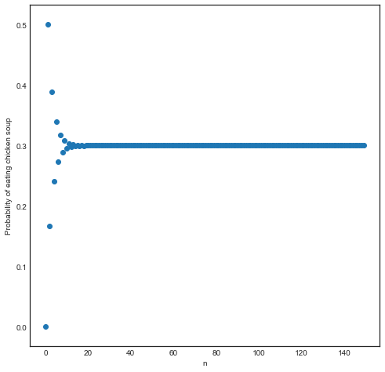

```python
import matplotlib.pyplot as plt
# Figure size is Figure size 800x800 with 1 Axes
plt.figure(figsize = (8, 8))
plt.scatter(list(range(0, N)),Xn[1,range(0,N)])
plt.xlabel('n')
plt.ylabel('Probability of eating chicken soup')
plt.show()
```

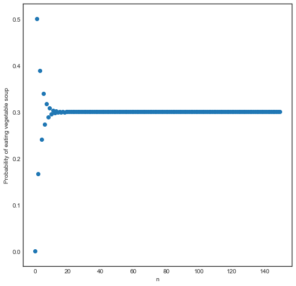

```python
import matplotlib.pyplot as plt
# Figure size is Figure size 800x800 with 1 Axes
plt.figure(figsize = (8, 8))
plt.scatter(list(range(0, N)),Xn[2,range(0,N)])
plt.xlabel('n')
plt.ylabel('Probability of eating vegetable soup')
plt.show()
```